# **Objectives of the study**

1. To make a basic EDA on the data
2. To study and visualise different parameters with different hypothesis testing.
3. To find the relationship between different parameters

```python
%matplotlib inline

import datetime as dt
import pandas as pd
import numpy as np
import matplotlib
import seaborn as sns
import scipy.stats as stats
import matplotlib.pyplot as plt
matplotlib.style.use('ggplot')
```

```python
var = pd.read_csv('/content/Uber project dataset.csv')
```

```python
var.head(10)
```

|  | Start_date | Start_day | Start_time | SHour | End_date | End_day | End_time | Duration | Duration_min | Category | Pickup | Destination | KM | Purpose | Driver_Rating | Fare | Tip | Payment_Type | Payment_Method | Status |
| --- | --- | --- | --- | --- | --- | --- | --- | --- | --- | --- | --- | --- | --- | --- | --- | --- | --- | --- | --- | --- |
| 0 | 01-Jan-16 | Friday | 22:54:00 | 22 | 01-Jan-16 | Friday | 01:39:00 | 02:45:00 | 165 | Business | Jacksonville | Kissimmee | 201.0 | Meeting | 0 | 6663.0 | 0 | Card | Card | Completed |
| 1 | 01-Jan-16 | Friday | 13:42:00 | 13 | 01-Jan-16 | Friday | 13:54:00 | 00:12:00 | 12 | Personal | Morrisville | Cary | 4.4 | Errand/Supplies | 4 | 175.2 | 17 | Digital | Uber Cash | Completed |
| 2 | 01-Jan-16 | Friday | 22:46:00 | 22 | 01-Jan-16 | Friday | 22:58:00 | 00:12:00 | 12 | Personal | Morrisville | Cary | 3.1 | Customer Visit | 0 | 132.3 | 13 | Digital | Gift Card | Completed |
| 3 | 03-Jan-16 | Sunday | 12:57:00 | 12 | 03-Jan-16 | Sunday | 13:08:00 | 00:11:00 | 11 | Business | Whitebridge | Edgehill Farms | 4.3 | Meal/Entertain | 3 | 171.9 | 17 | Card | Card | Completed |
| 4 | 03-Jan-16 | Sunday | 20:24:00 | 20 | 03-Jan-16 | Sunday | 20:40:00 | 00:16:00 | 16 | Business | Morrisville | Cary | 3.1 | Customer Visit | 3 | 132.3 | 13 | Digital | Uber Cash | Completed |
| 5 | 04-Jan-16 | Monday | 15:34:00 | 15 | 04-Jan-16 | Monday | 15:50:00 | 00:16:00 | 16 | Business | Cary | Cary | 5.9 | Meal/Entertain | 1 | 224.7 | 22 | Digital | Gift Card | Completed |
| 6 | 05-Jan-16 | Tuesday | 18:39:00 | 18 | 05-Jan-16 | Tuesday | 18:55:00 | 00:16:00 | 16 | Business | South Congress | The Drag | 2.7 | Errand/Supplies | 2 | 119.1 | 11 | Digital | UPI/e-Wallet | Completed |
| 7 | 05-Jan-16 | Tuesday | 12:29:00 | 12 | 05-Jan-16 | Tuesday | 12:42:00 | 00:13:00 | 13 | Personal | Kissimmee | Orlando | 3.6 | Customer Visit | 4 | 148.8 | 14 | Card | Card | Completed |
| 8 | 05-Jan-16 | Tuesday | 13:28:00 | 13 | 05-Jan-16 | Tuesday | 13:46:00 | 00:18:00 | 18 | Business | Lexington Park at Amberly | Westpark Place | 1.9 | Meeting | 5 | 92.7 | 9 | Card | Card | Completed |
| 9 | 06-Jan-16 | Wednesday | 13:42:00 | 13 | 06-Jan-16 | Wednesday | 14:01:00 | 00:19:00 | 19 | Business | Morrisville | Cary | 6.5 | Meal/Entertain | 4 | 244.5 | 24 | Card | Card | Completed |

```python
var.info()
```

```
<class 'pandas.core.frame.DataFrame'>
RangeIndex: 1155 entries, 0 to 1154
Data columns (total 20 columns):
 #   Column          Non-Null Count  Dtype
---  ------          --------------  -----
 0   Start_date      1155 non-null   object
 1   Start_day       1155 non-null   object
 2   Start_time      1155 non-null   object
 3   SHour           1155 non-null   int64
 4   End_date        1155 non-null   object
 5   End_day         1155 non-null   object
 6   End_time        1155 non-null   object
 7   Duration        1155 non-null   object
 8   Duration_min    1155 non-null   int64
 9   Category        1155 non-null   object
 10  Pickup          1155 non-null   object
 11  Destination     1155 non-null   object
 12  KM              1155 non-null   float64
 13  Purpose         1141 non-null   object
 14  Driver_Rating   1155 non-null   int64
 15  Fare            1155 non-null   float64
 16  Tip             1155 non-null   int64
 17  Payment_Type    1155 non-null   object
 18  Payment_Method  1155 non-null   object
 19  Status          1155 non-null   object
dtypes: float64(2), int64(4), object(14)
memory usage: 180.6+ KB
```

```python
print("Prints all the columns that are of numerical type")
var.select_dtypes(include=['number'])
```

```
Prints all the columns that are of numerical type
```

|  | SHour | Duration_min | KM | Driver_Rating | Fare | Tip |
| --- | --- | --- | --- | --- | --- | --- |
| 0 | 22 | 165 | 201.0 | 0 | 6663.0 | 0 |
| 1 | 13 | 12 | 4.4 | 4 | 175.2 | 17 |
| 2 | 22 | 12 | 3.1 | 0 | 132.3 | 13 |
| 3 | 12 | 11 | 4.3 | 3 | 171.9 | 17 |
| 4 | 20 | 16 | 3.1 | 3 | 132.3 | 13 |
| ... | ... | ... | ... | ... | ... | ... |
| 1150 | 20 | 9 | 3.0 | 4 | 129.0 | 12 |
| 1151 | 16 | 12 | 5.7 | 1 | 218.1 | 21 |
| 1152 | 13 | 19 | 10.4 | 5 | 373.2 | 37 |
| 1153 | 19 | 9 | 2.2 | 0 | 102.6 | 10 |
| 1154 | 19 | 9 | 2.9 | 5 | 125.7 | 12 |

1155 rows × 6 columns

```python
print("Prints all the columns that are of non-numerical type")
var.select_dtypes(include=['object'])
```

```
Prints all the columns that are of non-numerical type
```

|  | Start_date | Start_day | Start_time | End_date | End_day | End_time | Duration | Category | Pickup | Destination | Purpose | Payment_Type | Payment_Method | Status |
| --- | --- | --- | --- | --- | --- | --- | --- | --- | --- | --- | --- | --- | --- | --- |
| 0 | 01-Jan-16 | Friday | 22:54:00 | 01-Jan-16 | Friday | 01:39:00 | 02:45:00 | Business | Jacksonville | Kissimmee | Meeting | Card | Card | Completed |
| 1 | 01-Jan-16 | Friday | 13:42:00 | 01-Jan-16 | Friday | 13:54:00 | 00:12:00 | Personal | Morrisville | Cary | Errand/Supplies | Digital | Uber Cash | Completed |
| 2 | 01-Jan-16 | Friday | 22:46:00 | 01-Jan-16 | Friday | 22:58:00 | 00:12:00 | Personal | Morrisville | Cary | Customer Visit | Digital | Gift Card | Completed |
| 3 | 03-Jan-16 | Sunday | 12:57:00 | 03-Jan-16 | Sunday | 13:08:00 | 00:11:00 | Business | Whitebridge | Edgehill Farms | Meal/Entertain | Card | Card | Completed |
| 4 | 03-Jan-16 | Sunday | 20:24:00 | 03-Jan-16 | Sunday | 20:40:00 | 00:16:00 | Business | Morrisville | Cary | Customer Visit | Digital | Uber Cash | Completed |
| ... | ... | ... | ... | ... | ... | ... | ... | ... | ... | ... | ... | ... | ... | ... |
| 1150 | 30-Dec-16 | Friday | 20:48:00 | 30-Dec-16 | Friday | 20:57:00 | 00:09:00 | Business | Morrisville | Cary | Customer Visit | Digital | Uber Cash | Completed |
| 1151 | 31-Dec-16 | Saturday | 16:21:00 | 31-Dec-16 | Saturday | 16:33:00 | 00:12:00 | Business | Cary | Apex | Errand/Supplies | Digital | Uber Cash | Completed |
| 1152 | 31-Dec-16 | Saturday | 13:22:00 | 31-Dec-16 | Saturday | 13:41:00 | 00:19:00 | Business | Durham | Cary | Meeting | Digital | UPI/e-Wallet | Completed |
| 1153 | 31-Dec-16 | Saturday | 19:41:00 | 31-Dec-16 | Saturday | 19:50:00 | 00:09:00 | Business | Kenner | Kenner | Meeting | Digital | Uber Cash | Completed |
| 1154 | 31-Dec-16 | Saturday | 19:30:00 | 31-Dec-16 | Saturday | 19:39:00 | 00:09:00 | Business | Morrisville | Cary | Errand/Supplies | Card | Card | Completed |

1155 rows × 14 columns

**Extracting date parameters - Date, Day, Month, Year from the date column**

```python
var['Start_date']=pd.to_datetime(var['Start_date'])
```

```python
var['Date'] = var['Start_date'].dt.day
var['Month'] = var['Start_date'].dt.month
var['Year'] = var['Start_date'].dt.year
var['Weekday']=var['Start_date'].dt.day_name()
```

```python
print(var)
```

```
     Start_date Start_day Start_time  SHour   End_date   End_day  End_time  \
0    2016-01-01    Friday   22:54:00     22  01-Jan-16    Friday  01:39:00
1    2016-01-01    Friday   13:42:00     13  01-Jan-16    Friday  13:54:00
2    2016-01-01    Friday   22:46:00     22  01-Jan-16    Friday  22:58:00
3    2016-01-03    Sunday   12:57:00     12  03-Jan-16    Sunday  13:08:00
4    2016-01-03    Sunday   20:24:00     20  03-Jan-16    Sunday  20:40:00
...         ...       ...        ...    ...        ...       ...       ...
1150 2016-12-30    Friday   20:48:00     20  30-Dec-16    Friday  20:57:00
1151 2016-12-31  Saturday   16:21:00     16  31-Dec-16  Saturday  16:33:00
1152 2016-12-31  Saturday   13:22:00     13  31-Dec-16  Saturday  13:41:00
1153 2016-12-31  Saturday   19:41:00     19  31-Dec-16  Saturday  19:50:00
1154 2016-12-31  Saturday   19:30:00     19  31-Dec-16  Saturday  19:39:00

      Duration  Duration_min  Category  ... Driver_Rating    Fare  Tip  \
0     02:45:00           165  Business  ...             0  6663.0    0
```

[output cut: 25 more lines]

```python
[var.isna().any(axis=1)]
```

```
[0       False
 1       False
 2       False
 3       False
 4       False
         ...
 1150    False
 1151    False
 1152    False
 1153    False
 1154    False
 Length: 1155, dtype: bool]
```

```python
var[var.isna().any(axis=1)]
```

|  | Start_date | Start_day | Start_time | SHour | End_date | End_day | End_time | Duration | Duration_min | Category | ... | Driver_Rating | Fare | Tip | Payment_Type | Payment_Method | Status | Date | Month | Year | Weekday |
| --- | --- | --- | --- | --- | --- | --- | --- | --- | --- | --- | --- | --- | --- | --- | --- | --- | --- | --- | --- | --- | --- |
| 30 | 2016-01-11 | Monday | 14:26:00 | 14 | 11-Jan-16 | Monday | 14:31:00 | 00:05:00 | 5 | Business | ... | 1 | 105.9 | 10 | Digital | UPI/e-Wallet | Completed | 11 | 1 | 2016 | Monday |
| 62 | 2016-01-20 | Wednesday | 17:30:00 | 17 | 20-Jan-16 | Wednesday | 17:37:00 | 00:07:00 | 7 | Business | ... | 3 | 89.4 | 8 | Cash | Cash | Completed | 20 | 1 | 2016 | Wednesday |
| 121 | 2016-02-04 | Thursday | 23:45:00 | 23 | 04-Feb-16 | Thursday | 00:01:00 | 00:16:00 | 16 | Personal | ... | 2 | 119.1 | 11 | Card | Card | Completed | 4 | 2 | 2016 | Thursday |
| 166 | 2016-02-17 | Wednesday | 20:53:00 | 20 | 17-Feb-16 | Wednesday | 21:42:00 | 00:49:00 | 49 | Business | ... | 3 | 241.2 | 24 | Cash | Cash | Completed | 17 | 2 | 2016 | Wednesday |
| 415 | 2016-05-07 | Saturday | 18:42:00 | 18 | 07-May-16 | Saturday | 18:56:00 | 00:14:00 | 14 | Business | ... | 2 | 142.2 | 14 | Digital | UPI/e-Wallet | Completed | 7 | 5 | 2016 | Saturday |
| 434 | 2016-05-14 | Saturday | 17:50:00 | 17 | 14-May-16 | Saturday | 17:59:00 | 00:09:00 | 9 | Business | ... | 4 | 89.4 | 8 | Card | Card | Completed | 14 | 5 | 2016 | Saturday |
| 442 | 2016-05-16 | Monday | 20:47:00 | 20 | 16-May-16 | Monday | 20:53:00 | 00:06:00 | 6 | Business | ... | 1 | 69.6 | 6 | Card | Card | Completed | 16 | 5 | 2016 | Monday |
| 500 | 2016-06-05 | Sunday | 12:03:00 | 12 | 05-Jun-16 | Sunday | 12:21:00 | 00:18:00 | 18 | Business | ... | 0 | 353.4 | 35 | Digital | Uber Cash | Completed | 5 | 6 | 2016 | Sunday |
| 566 | 2016-07-01 | Friday | 17:02:00 | 17 | 01-Jul-16 | Friday | 17:27:00 | 00:25:00 | 25 | Business | ... | 5 | 492.0 | 49 | Card | Card | Completed | 1 | 7 | 2016 | Friday |
| 595 | 2016-07-11 | Monday | 22:16:00 | 22 | 11-Jul-16 | Monday | 22:34:00 | 00:18:00 | 18 | Business | ... | 1 | 254.4 | 0 | Digital | UPI/e-Wallet | Completed | 11 | 7 | 2016 | Monday |
| 621 | 2016-07-18 | Monday | 00:50:00 | 0 | 18-Jul-16 | Monday | 01:00:00 | 00:10:00 | 10 | Personal | ... | 1 | 89.4 | 8 | Digital | UPI/e-Wallet | Completed | 18 | 7 | 2016 | Monday |
| 624 | 2016-07-19 | Tuesday | 17:50:00 | 17 | 19-Jul-16 | Tuesday | 17:56:00 | 00:06:00 | 6 | Business | ... | 1 | 86.1 | 8 | Digital | Uber Cash | Completed | 19 | 7 | 2016 | Tuesday |
| 970 | 2016-11-07 | Monday | 12:47:00 | 12 | 07-Nov-16 | Monday | 13:04:00 | 00:17:00 | 17 | Business | ... | 1 | 234.6 | 23 | Card | Card | Completed | 7 | 11 | 2016 | Monday |
| 1102 | 2016-12-15 | Thursday | 21:16:00 | 21 | 15-Dec-16 | Thursday | 21:41:00 | 00:25:00 | 25 | Business | ... | 2 | 468.9 | 46 | Digital | UPI/e-Wallet | Completed | 15 | 12 | 2016 | Thursday |

14 rows × 24 columns

```python
var.dropna(axis=0, how="any", inplace=True)
var.shape
```

```
(1141, 24)
```

**Creating a pandas dataframe**

```python
df=pd.DataFrame(var)
print(df)
```

```
     Start_date Start_day Start_time  SHour   End_date   End_day  End_time  \
0    2016-01-01    Friday   22:54:00     22  01-Jan-16    Friday  01:39:00
1    2016-01-01    Friday   13:42:00     13  01-Jan-16    Friday  13:54:00
2    2016-01-01    Friday   22:46:00     22  01-Jan-16    Friday  22:58:00
3    2016-01-03    Sunday   12:57:00     12  03-Jan-16    Sunday  13:08:00
4    2016-01-03    Sunday   20:24:00     20  03-Jan-16    Sunday  20:40:00
...         ...       ...        ...    ...        ...       ...       ...
1150 2016-12-30    Friday   20:48:00     20  30-Dec-16    Friday  20:57:00
1151 2016-12-31  Saturday   16:21:00     16  31-Dec-16  Saturday  16:33:00
1152 2016-12-31  Saturday   13:22:00     13  31-Dec-16  Saturday  13:41:00
1153 2016-12-31  Saturday   19:41:00     19  31-Dec-16  Saturday  19:50:00
1154 2016-12-31  Saturday   19:30:00     19  31-Dec-16  Saturday  19:39:00

      Duration  Duration_min  Category  ... Driver_Rating    Fare  Tip  \
0     02:45:00           165  Business  ...             0  6663.0    0
```

[output cut: 25 more lines]

```python
df.nunique()
```

```
Start_date        352
Start_day           7
Start_time        685
SHour              23
End_date          352
End_day             7
End_time          675
Duration           99
Duration_min       99
Category            2
Pickup            175
Destination       183
KM                256
Purpose            10
Driver_Rating       6
Fare              256
Tip                86
Payment_Type        3
Payment_Method      5
Status              2
Date               31
Month              12
Year                1
Weekday             7
dtype: int64
```

```python
df.describe()
```

|  | SHour | Duration_min | KM | Driver_Rating | Fare | Tip | Date | Month | Year |
| --- | --- | --- | --- | --- | --- | --- | --- | --- | --- |
| count | 1141.000000 | 1141.000000 | 1141.000000 | 1141.000000 | 1141.000000 | 1141.000000 | 1141.000000 | 1141.000000 | 1141.0 |
| mean | 14.656442 | 23.609991 | 10.632340 | 2.549518 | 380.867222 | 24.914110 | 15.858896 | 6.518843 | 2016.0 |
| std | 4.565827 | 30.137047 | 21.697991 | 1.697380 | 716.033709 | 21.243484 | 8.859244 | 3.527939 | 0.0 |
| min | 0.000000 | 0.000000 | 0.500000 | 0.000000 | 46.500000 | 0.000000 | 1.000000 | 1.000000 | 2016.0 |
| 25% | 12.000000 | 10.000000 | 2.900000 | 1.000000 | 125.700000 | 10.000000 | 8.000000 | 3.000000 | 2016.0 |
| 50% | 15.000000 | 16.000000 | 6.000000 | 3.000000 | 228.000000 | 20.000000 | 16.000000 | 7.000000 | 2016.0 |
| 75% | 18.000000 | 28.000000 | 10.400000 | 4.000000 | 373.200000 | 35.000000 | 24.000000 | 10.000000 | 2016.0 |
| max | 23.000000 | 492.000000 | 310.300000 | 5.000000 | 10269.900000 | 127.000000 | 31.000000 | 12.000000 | 2016.0 |

**Findings about the parameters: Fare and Distance Travelled**

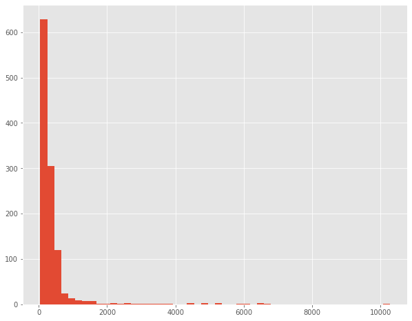

```python
plt.figure(figsize=(10,8))
plt.hist(df['Fare'],bins=50)
```

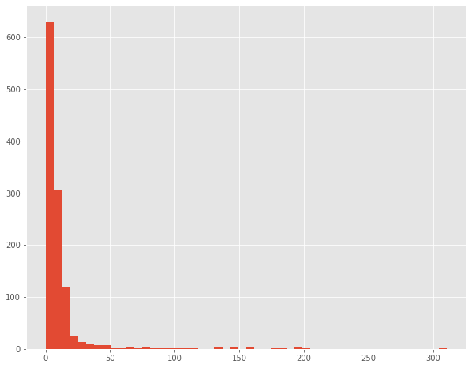

```python
plt.figure(figsize=(10,8))
plt.hist(df['KM'], bins=50)
```

From the above histograms, most of the fare amount falls between 0 - 2000 range and most of the distance travelled is shorter comparatively (0-50 Km).It is also found that the parameters "Kms travelled" and "Fare" are not normally distributed. In order to prove this statistically,we perform the following test:

**Shapiro test for normality testing**

```python
from scipy.stats import shapiro

norm=df['Fare']
stat, p = shapiro(norm)

print('stat=%.2f,p=%.30f'% (stat,p))

if p>0.05:
  print("Fare data normally distributed")
else:
  print("Fare data not normally distributed")
```

```
stat=0.35,p=0.000000000000000000000000000000
Fare data not normally distributed
```

```python
norm=df['KM']
stat, p = shapiro(norm)

print('stat=%.2f,p=%.30f'% (stat,p))

if p>0.05:
  print("Km data normally distributed")
else:
  print("Km data not normally distributed")
```

```
stat=0.35,p=0.000000000000000000000000000000
Km data not normally distributed
```

So, it is statistically proved that the considered data are not normally distributed by considering a 95% confidence.

**Outliers of fare and distance parameters**

From the previous section, it is found that the parameters "KM" and "Fare" are not normally distributed. So we can't able to perform z test for outlier testing. We can work with the outliers using the Five- Point Data Desctiption to work with outliers.

At first, we are creating Box plots for the parameters to visualize the outliers.

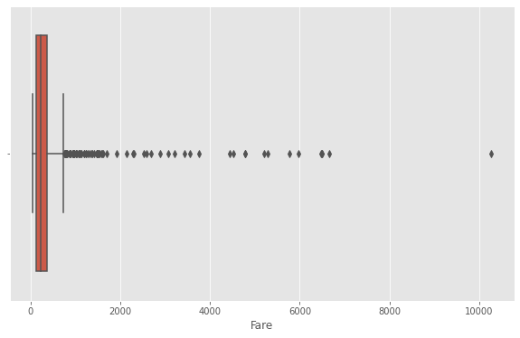

```python
plt.figure(figsize=(10,6))
sns.boxplot(x=df["Fare"])
```

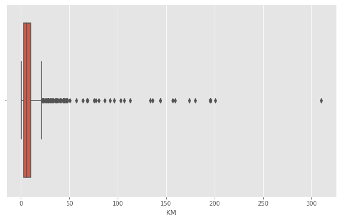

```python
plt.figure(figsize=(10,6))
sns.boxplot(x=df["KM"])
```

In this case, removing all the outliers of **Fare** and **Distance** parameters is not considerable, since they are the parameters that are eventual to happen. Instead, it is better to calculate a new parameter, **Fare per km** and removing the outliers based on that would be considerable, since the outliers in this case might be due to unexpected surge.

**Price/km distribution**

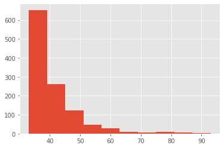

```python
df["Fare_per_km"] = df["Fare"] / df["KM"]
plt.hist(df["Fare_per_km"])
```

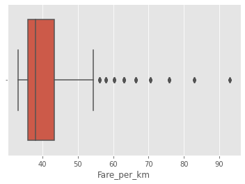

```python
sns.boxplot(df["Fare_per_km"])
```

```python
df["Fare_per_km"].describe()
```

```
count    1141.000000
mean       41.062355
std         8.363648
min        33.096681
25%        35.884615
50%        38.000000
75%        43.344828
max        93.000000
Name: Fare_per_km, dtype: float64
```

**Finding the quantiles of price/km parameter**

```python
def outer_boundary(data, variable):
  Q1 = data[variable].quantile(.25)
  Q3 = data[variable].quantile(.75)
  IQR = Q3 - Q1
  low_bound = Q1 - 1.5*IQR
  up_bound = Q3 + 1.5*IQR

  return low_bound, up_bound
```

```python
low, up = outer_boundary(df,"Fare_per_km")
print("Lower limit = ", low)
print("Upper limit = ", up)
```

```
Lower limit =  24.694297082228104
Upper limit =  54.53514588859417
```

The data falling away from the above boundaries are outliers. Here the values greater than 54.535 are outliers.

**Removal of outliers with reference to the lower and upper limit of the 5 point data description**

```python
df_outliers = np.where(df["Fare_per_km"] > up,True,np.where(df["Fare_per_km"] < low,True,False))
```

```python
df.shape
```

```
(1141, 25)
```

```python
df_new = df.loc[~(df_outliers),]
```

```python
df_new.shape
```

```
(1075, 25)
```

```python
df_new["Fare_per_km"].max()
```

```
54.42857142857143
```

```python
df_new["Fare_per_km"].min()
```

```
33.09668063164679
```

```python
df_new.describe()
```

|  | SHour | Duration_min | KM | Driver_Rating | Fare | Tip | Date | Month | Year | Fare_per_km |
| --- | --- | --- | --- | --- | --- | --- | --- | --- | --- | --- |
| count | 1075.000000 | 1075.000000 | 1075.000000 | 1075.000000 | 1075.000000 | 1075.000000 | 1075.000000 | 1075.000000 | 1075.0 | 1075.000000 |
| mean | 14.667907 | 24.682791 | 11.226512 | 2.533953 | 400.474884 | 26.208372 | 15.881860 | 6.523721 | 2016.0 | 39.487957 |
| std | 4.563890 | 30.720868 | 22.217617 | 1.696615 | 733.181364 | 21.203442 | 8.927809 | 3.539633 | 0.0 | 5.058784 |
| min | 0.000000 | 0.000000 | 1.400000 | 0.000000 | 76.200000 | 0.000000 | 1.000000 | 1.000000 | 2016.0 | 33.096681 |
| 25% | 12.000000 | 11.000000 | 3.100000 | 1.000000 | 132.300000 | 11.000000 | 8.000000 | 3.000000 | 2016.0 | 35.752294 |
| 50% | 15.000000 | 17.000000 | 6.200000 | 3.000000 | 234.600000 | 21.000000 | 16.000000 | 7.000000 | 2016.0 | 37.838710 |
| 75% | 18.000000 | 29.000000 | 10.900000 | 4.000000 | 389.700000 | 36.000000 | 24.000000 | 10.000000 | 2016.0 | 42.677419 |
| max | 23.000000 | 492.000000 | 310.300000 | 5.000000 | 10269.900000 | 127.000000 | 31.000000 | 12.000000 | 2016.0 | 54.428571 |

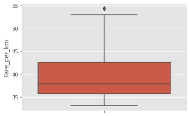

```python
sns.boxplot(y=df_new["Fare_per_km"])  #The outliers correponding to Fare per km of the dataset are removed and the new dataset aligns with the new IQR, Q1 and Q3 values. In this case, the below plot showing some outliers are specific to this updated dataset are considerable.
```

```python
df_new.describe() - df.describe()
```

|  | SHour | Duration_min | KM | Driver_Rating | Fare | Tip | Date | Month | Year | Fare_per_km |
| --- | --- | --- | --- | --- | --- | --- | --- | --- | --- | --- |
| count | -66.000000 | -66.000000 | -66.000000 | -66.000000 | -66.000000 | -66.000000 | -66.000000 | -66.000000 | -66.0 | -66.000000 |
| mean | 0.011465 | 1.072799 | 0.594172 | -0.015564 | 19.607662 | 1.294262 | 0.022965 | 0.004878 | 0.0 | -1.574398 |
| std | -0.001937 | 0.583821 | 0.519626 | -0.000765 | 17.147654 | -0.040041 | 0.068564 | 0.011693 | 0.0 | -3.304864 |
| min | 0.000000 | 0.000000 | 0.900000 | 0.000000 | 29.700000 | 0.000000 | 0.000000 | 0.000000 | 0.0 | 0.000000 |
| 25% | 0.000000 | 1.000000 | 0.200000 | 0.000000 | 6.600000 | 1.000000 | 0.000000 | 0.000000 | 0.0 | -0.132322 |
| 50% | 0.000000 | 1.000000 | 0.200000 | 0.000000 | 6.600000 | 1.000000 | 0.000000 | 0.000000 | 0.0 | -0.161290 |
| 75% | 0.000000 | 1.000000 | 0.500000 | 0.000000 | 16.500000 | 1.000000 | 0.000000 | 0.000000 | 0.0 | -0.667408 |
| max | 0.000000 | 0.000000 | 0.000000 | 0.000000 | 0.000000 | 0.000000 | 0.000000 | 0.000000 | 0.0 | -38.571429 |

From the above steps, the outliers based on fare per km are removed, due to which the 5 Point data description aligned with the new dataset, which produced some outliers for the fare per km value, but those values are considerable.

Also the difference in the 5 point data description before and after removing the outliers also presented.

```python
df_new.nunique()
```

```
Start_date        350
Start_day           7
Start_time        663
SHour              23
End_date          350
End_day             7
End_time          653
Duration           99
Duration_min       99
Category            2
Pickup            160
Destination       167
KM                247
Purpose            10
Driver_Rating       6
Fare              247
Tip                83
Payment_Type        3
Payment_Method      5
Status              2
Date               31
Month              12
Year                1
Weekday             7
Fare_per_km       247
dtype: int64
```

**Max and Min Fare details:**

```python
print("Max Fare details:")
print(" ")
print("Max Fare:",df_new.Fare[df_new.Fare==df_new.Fare.max()])
print("KM for Max Fare:",df_new.KM[df_new.Fare==df_new.Fare.max()])
print("Date:",df_new.Start_date[df_new.Fare==df_new.Fare.max()])
print("Date:",df_new.Weekday[df_new.Fare==df_new.Fare.max()])
```

```
Max Fare details:

Max Fare: 131    10269.9
Name: Fare, dtype: float64
KM for Max Fare: 131    310.3
Name: KM, dtype: float64
Date: 131   2016-02-06
Name: Start_date, dtype: datetime64[ns]
Date: 131    Saturday
Name: Weekday, dtype: object
```

```python
print("Min Fare details:")
print(" ")
print("Min Fare:",df_new.Fare[df_new.Fare==df_new.Fare.min()])
print("KM for Min Fare:",df_new.KM[df_new.Fare==df_new.Fare.min()])
print("Date:",df_new.Start_date[df_new.Fare==df_new.Fare.min()])
print("Date:",df_new.Weekday[df_new.Fare==df_new.Fare.min()])
```

```
Min Fare details:

Min Fare: 11      76.2
57      76.2
67      76.2
301     76.2
317     76.2
337     76.2
388     76.2
513     76.2
559     76.2
583     76.2
930     76.2
1039    76.2
1047    76.2
```

[output cut: 47 more lines]

# **STUDY OF RELATIONSHIP BETWEEN DIFFERENT PARAMETERS**

# *1 a. Correlation between Distance Travelled and Fare*

In general, it is known that whenever distance increases, Fare also inceases. In order to prove this, we are going to perform the collowing correlation tests:

**Null Hypothesis:** There's no correlation between Distance Travelled and Fare.

**Alternate Hypothesis**: There's a correlation between Distance Travelled and Fare.

**Test condition:** For a 95% confidence, if p value is less than 0.05, then reject null hypothesis, else accept null hypothesis.

```python
sample1 = df_new["KM"]
sample2 = df_new["Fare"]
```

```python
#Spearman Rank Correlation

from scipy.stats import spearmanr
corr, p = spearmanr(sample1, sample2)

print('corr=%.3f, p=%.3f' % (corr,p))

if p < 0.05:
  print("Reject Ho and accept Ha")
else:
  print("Reject Ha and accept H0")
```

```
corr=1.000, p=0.000
Reject Ho and accept Ha
```

```python
#Pearson Correlation

from scipy.stats import pearsonr
corr, p = pearsonr(sample1, sample2)

print('corr=%.3f, p=%.3f' % (corr,p))

if p < 0.05:
  print("Reject Ho and accept Ha")
else:
  print("Reject Ha and accept H0")
```

```
corr=1.000, p=0.000
Reject Ho and accept Ha
```

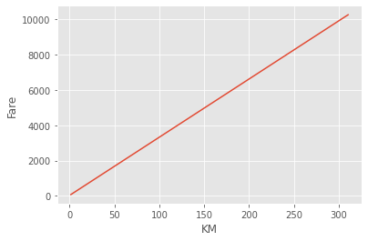

```python
sns.lineplot(data=df_new,x="KM",y="Fare")
```

Both the correlation tests resulted a correlation value of 1. This means that "Distance Travelled" and "Fare" parameters are in complete positive linear relationship. Also, from the above test, Null hypothesis is rejected.

So, "Distance Travelled" and "Fare" are correlated.

*1 b. Correlation between Distance Travelled and Time duration*

In general, it is known that whenever distance increases, Time also inceases. In order to prove this, we are going to perform the collowing correlation tests:

**Null Hypothesis:** There's no relation between Distance Travelled and Time Duration

**Alternate Hypothesis**: There's a between Distance Travelled and Time Duration

**Test condition:** For a 95% confidence, if p value is less than 0.05, then reject null hypothesis, else accept null hypothesis.

```python
sample_1 = df_new["KM"]
sample_2 = df_new["Duration_min"]
```

```python
#Spearman Rank Correlation

from scipy.stats import spearmanr
corr, p = spearmanr(sample_1, sample_2)

print('corr=%.3f, p=%.3f' % (corr,p))

if p < 0.05:
  print("Reject Ho and accept Ha")
else:
  print("Reject Ha and accept H0")
```

```
corr=0.784, p=0.000
Reject Ho and accept Ha
```

```python
#Pearson Correlation

from scipy.stats import pearsonr
corr, p = pearsonr(sample_1, sample_2)

print('corr=%.3f, p=%.3f' % (corr,p))

if p < 0.05:
  print("Reject Ho and accept Ha")
else:
  print("Reject Ha and accept H0")
```

```
corr=0.748, p=0.000
Reject Ho and accept Ha
```

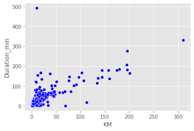

```python
sns.scatterplot(data=df_new, x="KM", y="Duration_min",color="blue")
```

The correlation values from both the above tests are greater than 0.05. Also, both tests results in the rejection of null hypothesis.

So, There's a positive relationship between "Distance Travelled" and "Time taken".

**Conclusion:**

Both the above tests for **Distance Travelled** vs **Time duration** as well as **Distance Travelled** vs **Fare** resulted in a positive linear relationship.

# *2. Uber got more revenue from Non - cash payments than from cash payment*

In order to check whether there's an effect of method of payment an revenue, we perform One-way Anova test.

**One way Anova Testing:**

**Null Hypothesis H0**: There's no relation between type of payment and the revenue.

**Alternate Hypothesis Ha**: There's relation between type of payment and the revenue.

**Significance value (alpha)** = 0.05

```python
data1 = df_new[["Payment_Type","Fare"]]
data1
```

|  | Payment_Type | Fare |
| --- | --- | --- |
| 0 | Card | 6663.0 |
| 1 | Digital | 175.2 |
| 2 | Digital | 132.3 |
| 3 | Card | 171.9 |
| 4 | Digital | 132.3 |
| ... | ... | ... |
| 1150 | Digital | 129.0 |
| 1151 | Digital | 218.1 |
| 1152 | Digital | 373.2 |
| 1153 | Digital | 102.6 |
| 1154 | Card | 125.7 |

1075 rows × 2 columns

```python
#replacing character values to numeric values in Payment_type column
#Cash = 1, Card =2, Digital =3

data1['Payment_Type'].replace(['Cash', 'Card','Digital'],
                        [1,2,3], inplace=True)
data1
```

|  | Payment_Type | Fare |
| --- | --- | --- |
| 0 | 2 | 6663.0 |
| 1 | 3 | 175.2 |
| 2 | 3 | 132.3 |
| 3 | 2 | 171.9 |
| 4 | 3 | 132.3 |
| ... | ... | ... |
| 1150 | 3 | 129.0 |
| 1151 | 3 | 218.1 |
| 1152 | 3 | 373.2 |
| 1153 | 3 | 102.6 |
| 1154 | 2 | 125.7 |

1075 rows × 2 columns

```python
import statsmodels.api as sm
from statsmodels.formula.api import ols

new = ols('Fare ~ Payment_Type', data = data1).fit()
```

```python
anovaRes = sm.stats.anova_lm(new,typ=2)
anovaRes['PR(>F)']
```

```
Payment_Type    0.944015
Residual             NaN
Name: PR(>F), dtype: float64
```

Also, the p-value is very high = 0.944

0.944 > 0.05

Here, wew are accepting the null hypothesis, that the average revenue made by all the modes of payment are same.

**Number of rides for modes of payment**

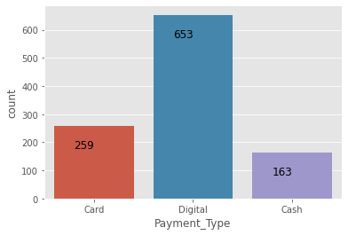

```python
x=sns.countplot(x=df_new['Payment_Type'])
for p in x.patches:
    x.annotate(f'\n{p.get_height()}', (p.get_x()+0.2, p.get_height()), ha='left', va='top', color='black', size=12)
```

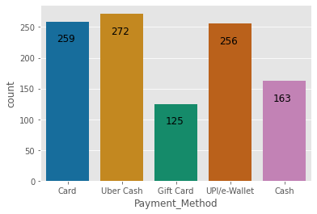

```python
sns.set_palette("colorblind")
x=sns.countplot(x=df_new['Payment_Method'])
for p in x.patches:
    x.annotate(f'\n{p.get_height()}', (p.get_x()+0.2, p.get_height()), ha='left', va='top', color='black', size=12)
```

**Revenue based on different types of payment**

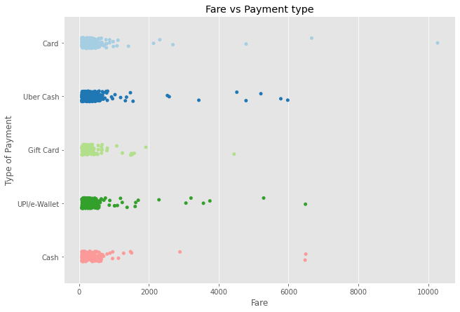

```python
plt.figure(figsize=(10,7))
sns.set_palette("Paired")
plot=sns.stripplot(y=df_new['Payment_Method'],x=df['Fare'])
plot.set(xlabel='Fare',ylabel= 'Type of Payment',title='Fare vs Payment type')
plt.show()
```

```python
data = df_new.groupby("Payment_Method")["Fare"].sum()
data
#grouping the data based on the type of fares
```

```
Payment_Method
Card            100463.7
Cash             66279.9
Gift Card        47577.3
UPI/e-Wallet    101030.4
Uber Cash       115159.2
Name: Fare, dtype: float64
```

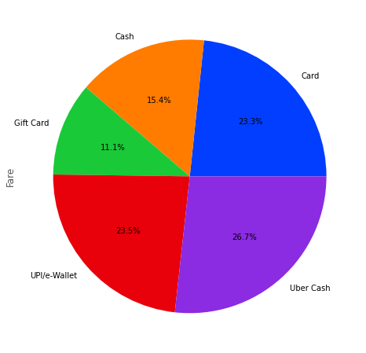

```python
sns.set_palette("bright")
plt.figure(figsize=(10,8))
data.plot.pie(autopct="%.1f%%")
```

It is found that Uber got more revenue from non-cash payments (84.6%) than cash payments (15.4%). Here Uber cash (Uber wallet payment) is the topmost contributor of payment mode followed by UPI payments.

**Conclusion:**

From the above analysis it is found that, the sum of revenue made by the digital payments is more than the card and cash payments.

But, proportionally, the number of digital payments made are higher comparatively to the other modes of payments.

This makes the average revenue made by different payment types are similar eventhough digital payments collected more revenue.

# *3. The Purpose of rides are having an effect on the days of the rides happened*

In this test, we are about to determine whether there's any effect of weekdays parameter on the purpose of usage . ( Maybe weekends with more usage form Meal/Entertainment and weekdays with official activities).

**Chi - Square Hypothesis Testing:**

For the comparision of 2 categorical variables, we are going to perform **chi-square test**.

**Null Hypothesis H0:** There's no relation between Weekday and Purpose.

**Alternate Hypothesis Ha:** There's a relation between Weekday and Purpose.

**Significance value (alpha):** 0.05.

```python
tab = pd.crosstab(df_new.Weekday, df_new.Purpose)   #creating a crosstab of 2 columns
tab
```

| Purpose Weekday | Airport/Travel | Between Offices | Charity ($) | Commute | Customer Visit | Errand/Supplies | Meal/Entertain | Meeting | Moving | Temporary Site |
| --- | --- | --- | --- | --- | --- | --- | --- | --- | --- | --- |
| Friday | 5 | 2 | 0 | 0 | 16 | 21 | 45 | 51 | 0 | 15 |
| Monday | 8 | 5 | 0 | 0 | 15 | 17 | 49 | 32 | 0 | 8 |
| Saturday | 7 | 6 | 0 | 0 | 20 | 18 | 38 | 45 | 1 | 14 |
| Sunday | 3 | 5 | 0 | 0 | 24 | 27 | 46 | 46 | 0 | 17 |
| Thursday | 3 | 2 | 0 | 0 | 21 | 19 | 39 | 48 | 0 | 16 |
| Tuesday | 10 | 3 | 0 | 0 | 18 | 23 | 39 | 44 | 2 | 18 |
| Wednesday | 3 | 2 | 1 | 1 | 19 | 24 | 51 | 43 | 1 | 19 |

```python
from scipy.stats import chi2_contingency
stat,p,dof,expected = chi2_contingency(tab)
print("stat=%.3f, p=%.3f" % (stat,p))
```

```
stat=47.538, p=0.720
```

```python
if p < 0.05:
    print("Reject H0 and accept Ha")
else:
    print("Accept H0 and reject Ha")
```

```
Accept H0 and reject Ha
```

From the above, the stat value (difference between observed and expected values) is considerably larger and from the test results, it is clear that , there's no relationship between the **Weekdays** and the **Purpose** parameters.

**Ride Category**

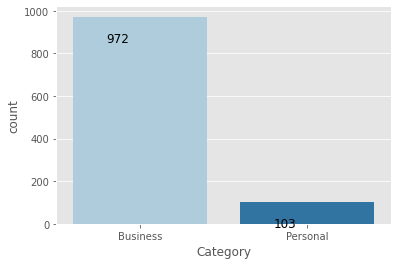

```python
sns.set_palette("Paired")
x=sns.countplot(x=df_new['Category'])
for p in x.patches:
    x.annotate(f'\n{p.get_height()}', (p.get_x()+0.2, p.get_height()), ha='left', va='top', color='black', size=12)
```

It is clearly visible that more number of rides are made for business purposes than for personal.

**Purpose of rides**

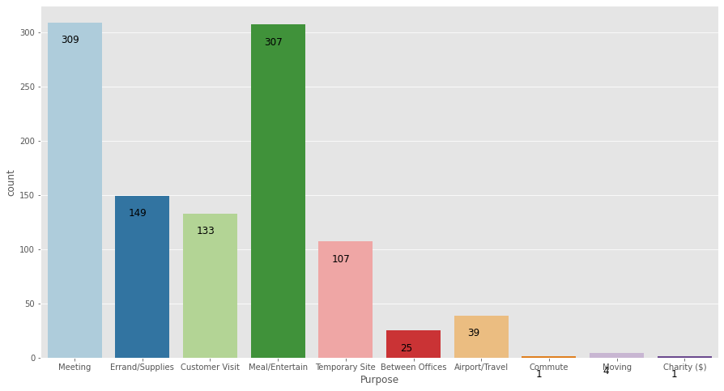

```python
plt.figure(figsize=(15,8))
x = sns.countplot(x=df_new['Purpose'])
for p in x.patches:
    x.annotate(f'\n{p.get_height()}', (p.get_x()+0.2, p.get_height()), ha='left', va='top', color='black', size=12)
```

It is clearly evident that users use Uber mainly for Meeting and Entertainment activities than for other activities like Supplies, Customer Visit, Airport / Travel etc. Also they use the least for Charity and other commute activities.

# *4. Other data plots*

**I. Trips and Driver rating**

```python
freq_table = pd.crosstab(df_new['Driver_Rating'],'no_of_drivers')
freq_table
```

| col_0 Driver_Rating | no_of_drivers |
| --- | --- |
| 0 | 171 |
| 1 | 180 |
| 2 | 169 |
| 3 | 192 |
| 4 | 185 |
| 5 | 178 |

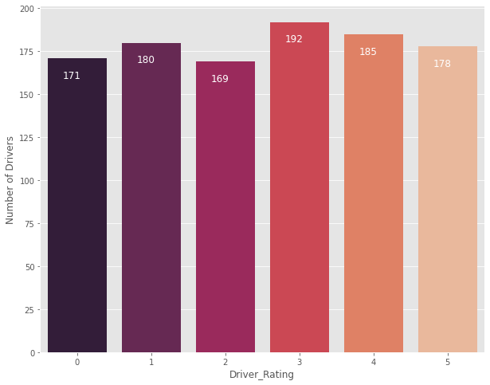

```python
plt.figure(figsize=(10,8))
sns.set_palette("rocket")
x=sns.countplot(x=df_new['Driver_Rating'])
plt.ylabel('Number of Drivers')
for p in x.patches:
    x.annotate(f'\n{p.get_height()}', (p.get_x()+0.2, p.get_height()), ha='left', va='top', color='white', size=12)
```

From the above plot, it is found that the number of trips with different driver rating lies bwtween 169 and 192. Around **180** trips falls under **"1 star driver rating"** and around **178** trips falls under **"5 star driver rating"**. 171 trips weren't rated. **Highest number of drivers** falls under **"3 Star rating"** and **lowest number of drivers** falls under **"2 star rating"**.

**II. Month vs Number of Trips**

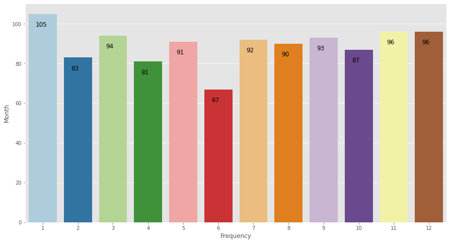

```python
sns.set_palette("Paired")
plt.figure(figsize=(15,8))
x=sns.countplot(x=df_new['Month'])
x.set(xlabel="Frequency",ylabel="Month")
for p in x.patches:
    x.annotate(f'\n{p.get_height()}', (p.get_x()+0.2, p.get_height()), ha='left', va='top', color='black', size=12)
```

From the plot, it is found that the month **January** records more number of trips and **June** records the less number of trips.

**III. Day vs Number of Trips**

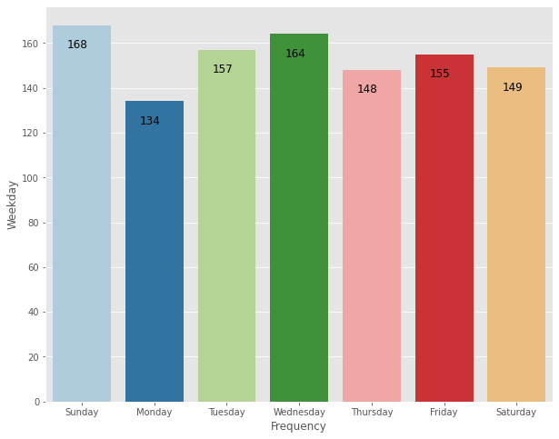

```python
plt.figure(figsize=(10,8))
order = ["Sunday", "Monday", "Tuesday", "Wednesday", "Thursday", "Friday", "Saturday"]
x=sns.countplot(x=df_new["Weekday"], order=order)
x.set(xlabel="Frequency",ylabel="Weekday")
for p in x.patches:
    x.annotate(f'\n{p.get_height()}', (p.get_x()+0.2, p.get_height()), ha='left', va='top', color='black', size=12)
```

When aggredated based on weekdays, **Sunday** records the **most** number of trips. This might be due to the fact that people spend their weekend in travelling.Followed by **Wednesday** lies on the 2nd position. On the other hand, **Monday** records the **least** number of trips.

**IV. Time vs Frequency**

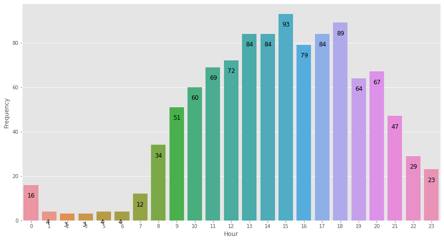

```python
sns.set_palette("pastel")
plt.figure(figsize=(15,8))
x=sns.countplot(x=df_new['SHour'])
x.set(xlabel="Hour",ylabel="Frequency")
for p in x.patches:
    x.annotate(f'\n{p.get_height()}', (p.get_x()+0.2, p.get_height()), ha='left', va='top', color='black', size=12)
```

The above plot is showing almost the expected results:

- From Midnight to Early morning, records the lowest number of requests.
- It gradually increases around the morning peak hour - 9AM to 12 Noon
- Likewise, the frequency gradually reduces over the evening peak hour from 17:00 hr towards midnight, it marks the least number of requests.
- But unexpectedly, the number of requests peaked at 13:00 - 15:00 hr.

**V. Number of trips completed**

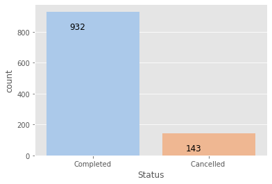

```python
x=sns.countplot(x=df_new["Status"])
for p in x.patches:
    x.annotate(f'\n{p.get_height()}', (p.get_x()+0.2, p.get_height()), ha='left', va='top', color='black', size=12)
```

**VI. Revenue based on purpose of trips**

```python
purpose = df_new.groupby("Purpose")["Fare"].sum()
purpose
```

```
Purpose
Airport/Travel      17079.3
Between Offices      8366.4
Charity ($)           528.3
Commute              5976.6
Customer Visit      80691.9
Errand/Supplies     30021.9
Meal/Entertain     106197.0
Meeting            139326.3
Moving                994.5
Temporary Site      41328.3
Name: Fare, dtype: float64
```

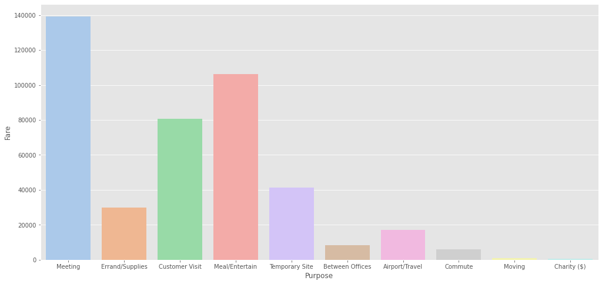

```python
plt.figure(figsize=(17,8))
x=sns.barplot(x="Purpose", y="Fare", data=df_new,ci = None, estimator=sum)
```

Based on purpose, Uber collected the maximum revenue in Meeting(140000), Meal/ Entertainment(105000) and Customer Visit(80000)

**VII. PAIRPLOTS**

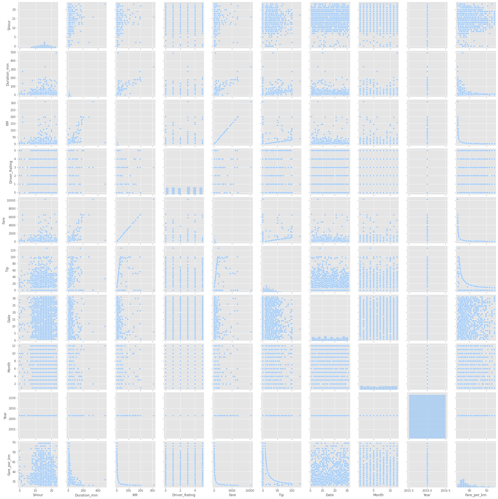

```python
sns.pairplot(df_new)
```

**VIII. CORRELATION MATRIX**

```python
correlation=df_new.corr()
```

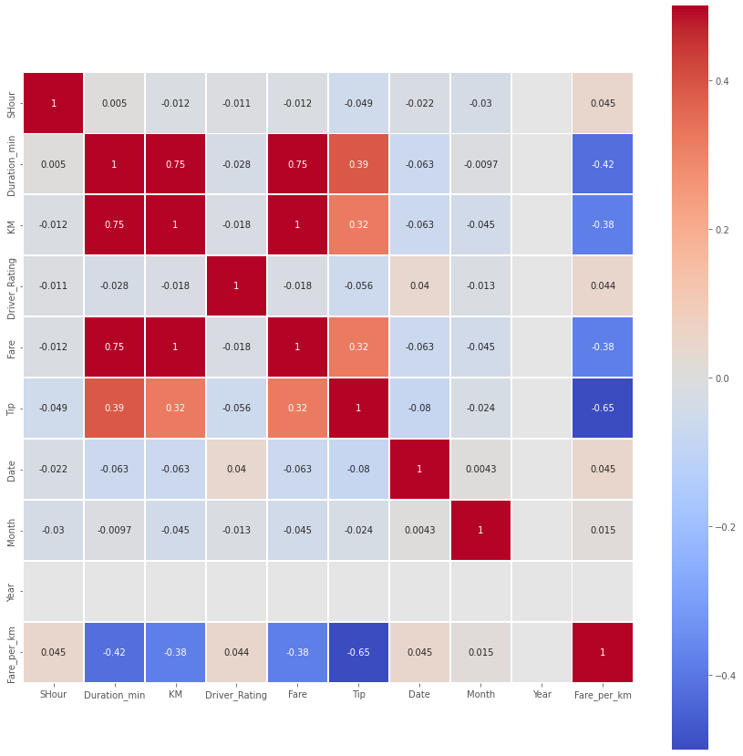

```python
plt.figure(figsize=(15,15))
sns.heatmap(correlation,cmap="coolwarm",annot=True,vmax=.5,vmin=-.5,center=0,square=True,linewidths=.5)
```

From the above correlation heatmap,

**Highly Correlated:**

1. Positive correlation:
   - Km vs Duration_min
   - Duration_min vs Fare
   - KM vs Fare
2. Negative correlation:
   - Fare_per_km vs Tip

**Moderately correlated**

1. Positive correlation:
   - KM vs Tip
   - Duration_min vs Tip
   - Fare vs Tip
2. Negative correlation:
   - KM vs Fare_per_km
   - Fare vs Fare_per_km

```python
!sudo apt-get install texlive-xetex texlive-fonts-recommended texlive-plain-generic
```

[output not shown]

```python
!jupyter nbconvert --to html /content/EDA_Uber.ipynb
```

```
[NbConvertApp] Converting notebook /content/EDA_Uber.ipynb to html
[NbConvertApp] Writing 1637947 bytes to /content/EDA_Uber.html
```